# Digit Clustering with autoencoder

The aim is to learn the best non-linear features on a set of mnist digits to clusterize them. Previous attempts have been made with raw/PCA/Restricted Bolzman Machine feature using KMeans and the result was around 0.55 of overall cluster purity (the purity is defined as the count of the most present digit in a cluster divided by the cluster size).

We will try to go deeper here using multilayer autoencoder.

```python
import tensorflow as tf
from datetime import datetime
import pylab as pl
from random import sample
import matplotlib.pyplot as plt
import seaborn as sns
import pylab as pl
from IPython.display import display, clear_output
from random import sample
import numpy as np
%matplotlib inline
from tensorflow.examples.tutorials.mnist import input_data
mnist = input_data.read_data_sets("MNIST_data/", one_hot=True)

import plotly
import plotly.offline as py
plotly.offline.init_notebook_mode()
```

```
Extracting MNIST_data/train-images-idx3-ubyte.gz
Extracting MNIST_data/train-labels-idx1-ubyte.gz
Extracting MNIST_data/t10k-images-idx3-ubyte.gz
Extracting MNIST_data/t10k-labels-idx1-ubyte.gz
```

**Data Overview**

```python
min_value = np.min(mnist.train.images)
max_value = np.max(mnist.train.images)

print("Image encoded pixel x with %.2f < x < %.2f" % (min_value, max_value))
```

```
Image encoded pixel x with 0.00 < x < 1.00
```

```python
def plot_d(digit, shape):
    plt.axis('off')
    plt.imshow(digit.reshape(shape), cmap='Greys_r')

def plot_ds(digits, title, shape):
    n=digits.shape[0]
    n_rows=n/25+1
    n_cols=25
    plt.figure(figsize=(n_cols * 0.9, n_rows * 1.3))
    plt.subplots_adjust(wspace=0, hspace=0)
    plt.suptitle(title, fontsize=16)
    for i in range(n):
        plt.subplot(n_rows, n_cols, i + 1)
        plot_d(digits[i,:], shape)

def random_batch(inputs, size):
    return inputs[np.random.randint(inputs.shape[0],size=(size)),:]

def random_var(shape):
    return tf.Variable(tf.random_normal(shape))

def variable_summaries(var, name):
  """Attach a lot of summaries to a Tensor."""
  with tf.name_scope('summaries'):
    mean = tf.reduce_mean(var)
    tf.scalar_summary('mean/' + name, mean)
    with tf.name_scope('stddev'):
      stddev = tf.sqrt(tf.reduce_mean(tf.square(var - mean)))
    tf.scalar_summary('stddev/' + name, stddev)
    tf.scalar_summary('max/' + name, tf.reduce_max(var))
    tf.scalar_summary('min/' + name, tf.reduce_min(var))
    tf.histogram_summary(name, var)

def scatter_3d(X, Y, title):
    data = []

    scatter = {
        'mode':"markers",
        'name': "y",
        'type': "scatter3d",
        'x': X[:,0],
        'y': X[:,1],
        'z': X[:,2],
        'marker': {'size':2, 'color':Y, 'colorscale':'Rainbow'}
    }
    data.append(scatter)

    fig = {'data':data, 'layout': {'title':title}}
    py.iplot(fig)

def scatter_2d(X, Y, title):
    data = []
    scatter = {
        'mode':"markers",
        'name': "y",
        'type': "scatter",
        'x': X[:,0],
        'y': X[:,1],
        'marker': {'size':3, 'color':Y, 'colorscale':'Rainbow'}
    }
    data.append(scatter)
    fig = {'data':data, 'layout': {'title':title}}
    py.iplot(fig)
```

```python
class TrainingParams:

    def __init__(self, batch_size, display_step, learn_rate):
        self.batch_size = batch_size
        self.display_step = display_step
        self.learn_rate = learn_rate

class AutoEncoderLayer:

    def __init__(self, inputs, shape, name):
        with tf.name_scope(name):
            self.name = name
            self.input_size = shape[0]
            self.output_size = shape[1]
            self.inputs = inputs
            with tf.name_scope('weights'):
                self.weights = tf.Variable(tf.random_normal(shape))
                variable_summaries(self.weights, name + '/weights')
            with tf.name_scope('bias'):
                self.bias = tf.Variable(tf.random_normal([self.output_size]))
                variable_summaries(self.bias, name + '/biases')

            self.model = AutoEncoderLayer.build_model(self.inputs, self.weights, self.bias)
            tf.histogram_summary(name + '/activations', self.model)

            # pre-trainig operations
            self.pretrain_params = TrainingParams(100, 100, 0.01)
            self.pretrain_model = self.build_pretrain_model()

    def build_pretrain_model(self):
        visible_bias = random_var([self.input_size])
        model_up = self.model
        model_down = AutoEncoderLayer.build_model(model_up, tf.transpose(self.weights), visible_bias)
        beta = 0.001
        self.pretrain_loss = tf.nn.l2_loss((self.inputs - model_down)) + (tf.nn.l2_loss(self.weights)*beta)
        # only train weights and bias variable so that the weight update is not propagated to the input layers
        self.pretrain_step = tf.train.RMSPropOptimizer(self.pretrain_params.learn_rate) \
            .minimize(self.pretrain_loss, var_list=[self.weights, self.bias])

        #tf.scalar_summary('pretraining/' + self.name + '/loss', self.pretrain_loss)

        return model_down

    def build_model(inputs, weights, bias):
        model =  tf.nn.sigmoid(tf.matmul(inputs, weights) + bias)
        return model

    # pretrain the layer without updating the weight of the other layers in the network
    def pretrain(self, train_set, network_inputs):
        total_batch = int(train_set.num_examples / self.pretrain_params.batch_size)
        for i in range(total_batch):
            batch_x, _ = train_set.next_batch(self.pretrain_params.batch_size)
            _, cost = sess.run([self.pretrain_step, self.pretrain_loss], feed_dict={network_inputs: batch_x})

            if i % self.pretrain_params.display_step == 0:
                print("Layer %s pretraining, Iteration %d, cost: %.4f" % (self.name, i, cost))

        print("%s layer pre-training done. Cost: %.5f" % (self.name, cost))

class AutoEncoderNetwork:

    def __init__(self, shape):
        self.learning_rate = 0.01
        self.epochs = 10
        self.batch_size = 100
        self.display_step = 100

        encode_shape = shape.copy()
        decode_shape = encode_shape.copy()
        decode_shape.reverse()

        self.inputs = tf.placeholder(tf.float32, [None, shape[0]])

        print("Autoencoder shape : %s" % (encode_shape))

        with tf.name_scope('network'):
            self.encoder, self.encoder_layers = AutoEncoderNetwork.build_network(self.inputs, encode_shape, 'encode')
            self.decoder, self.decoder_layers = AutoEncoderNetwork.build_network(self.encoder.model, decode_shape, 'decode')
            self.layers = self.encoder_layers + self.decoder_layers

        with tf.name_scope('mse_loss'):
            y = self.decoder.model

            # using l2 regularization on all the weight of the nural network
            weight_loss = tf.constant(0, dtype=tf.float32)
            beta = 0.001
            for layer in self.layers:
                weight_loss = weight_loss + (tf.nn.l2_loss(layer.weights) * beta)

            self.loss = tf.nn.l2_loss((self.inputs - y)) + weight_loss

            self.train_step = tf.train.RMSPropOptimizer(self.learning_rate).minimize(self.loss)

            tf.scalar_summary('loss', self.loss)

        with tf.name_scope('image_summary'):

            # track reconstructed images in tensboard
            original_images = tf.reshape(self.inputs, [-1, 28, 28, 1])
            tf.image_summary("origin", original_images, max_images=3)

            decoded_images = tf.reshape(self.decoder.model, [-1, 28, 28, 1])
            tf.image_summary("reconstructed", decoded_images, max_images=3)

        print("Autoencoder initialized")

    def build_network(inputs, shape, name):
        n_layers = len(shape)
        if n_layers < 2:
            raise Execption("You give at least 2 value for network shape (input and output size)")
        layers = []
        previous_inputs = inputs
        for i in range(1, n_layers):
            layer_shape = [shape[i - 1], shape[i]]
            layer = AutoEncoderLayer(previous_inputs, layer_shape, "%s_%d" % (name, i))
            layers.append(layer)
            previous_inputs = layer.model
        return layer, layers

    def pretrain(self, train_set):
        for l in self.layers:
            l.pretrain(train_set, self.inputs)

    def train(self, sess, train_set, test_set):
        total_batch = int(train_set.num_examples / self.batch_size)

        merged_summaries = tf.merge_all_summaries()
        summaries_dir = '/tmp/sbrouil/tensorboard/%s' % (datetime.now().strftime("%Y%m%d-%H%M%S"))
        summary_writer = tf.train.SummaryWriter(summaries_dir, sess.graph)

        sess.run(tf.initialize_all_variables())

        self.pretrain(train_set)
        for epoch in range(self.epochs):
            for i in range(total_batch):
                # train
                batch_x, _ = train_set.next_batch(self.batch_size)
                _, train_cost = sess.run([self.train_step, self.loss], feed_dict={self.inputs: batch_x})

                # test
                # batch_test_x, _ = test_set.next_batch(self.batch_size)
                # test_cost = sess.run(self.loss, feed_dict={self.inputs: batch_test_x})
                #test_writer.add_summary(summary, global_step)

                if i % 100 == 0:
                    summary = sess.run(merged_summaries, feed_dict={self.inputs: batch_x})
                    summary_writer.add_summary(summary, epoch * total_batch + i)
                    summary_writer.flush()
                    print("Epoch %d, iteration %d, cost %.4f" % (epoch, i, train_cost))

        print("Training done")
```

### Training the autoencoder

We get an embedded representation of the original digits into a vector of 10 elements using the autoencoder.

```python
autoencoder = AutoEncoderNetwork([28*28, 700, 250, 50, 10])
```

```
Autoencoder shape : [784, 700, 250, 50, 10]
Autoencoder initialized
```

```python
sess = tf.Session()

encode1_weights_img = tf.reshape(autoencoder.encoder_layers[0].weights, (-1, 28, 28, 1))
tf.image_summary("encode1_weight", encode1_weights_img, max_images=10)

autoencoder.train(sess, mnist.train, mnist.test)
```

```
Layer encode_1 pretraining, Iteration 0, cost: 17427.2344
Layer encode_1 pretraining, Iteration 100, cost: 1083.3464
Layer encode_1 pretraining, Iteration 200, cost: 895.7771
Layer encode_1 pretraining, Iteration 300, cost: 877.3605
Layer encode_1 pretraining, Iteration 400, cost: 774.4700
Layer encode_1 pretraining, Iteration 500, cost: 770.0671
encode_1 layer pre-training done. Cost: 822.92480
Layer encode_2 pretraining, Iteration 0, cost: 11936.1680
Layer encode_2 pretraining, Iteration 100, cost: 4828.2764
Layer encode_2 pretraining, Iteration 200, cost: 4004.9854
Layer encode_2 pretraining, Iteration 300, cost: 3587.0344
Layer encode_2 pretraining, Iteration 400, cost: 3278.1677
Layer encode_2 pretraining, Iteration 500, cost: 3138.8352
encode_2 layer pre-training done. Cost: 3023.96143
Layer encode_3 pretraining, Iteration 0, cost: 4260.3984
Layer encode_3 pretraining, Iteration 100, cost: 1910.0308
Layer encode_3 pretraining, Iteration 200, cost: 1526.2100
Layer encode_3 pretraining, Iteration 300, cost: 1394.5564
Layer encode_3 pretraining, Iteration 400, cost: 1201.6383
Layer encode_3 pretraining, Iteration 500, cost: 1190.2548
encode_3 layer pre-training done. Cost: 1119.85974
Layer encode_4 pretraining, Iteration 0, cost: 775.4930
Layer encode_4 pretraining, Iteration 100, cost: 394.8499
Layer encode_4 pretraining, Iteration 200, cost: 335.1033
Layer encode_4 pretraining, Iteration 300, cost: 304.0246
Layer encode_4 pretraining, Iteration 400, cost: 283.0763
Layer encode_4 pretraining, Iteration 500, cost: 286.7013
encode_4 layer pre-training done. Cost: 284.69205
Layer decode_1 pretraining, Iteration 0, cost: 63.3677
Layer decode_1 pretraining, Iteration 100, cost: 1.6786
Layer decode_1 pretraining, Iteration 200, cost: 1.3408
Layer decode_1 pretraining, Iteration 300, cost: 1.2185
Layer decode_1 pretraining, Iteration 400, cost: 1.1783
Layer decode_1 pretraining, Iteration 500, cost: 1.1071
decode_1 layer pre-training done. Cost: 1.20483
Layer decode_2 pretraining, Iteration 0, cost: 647.7791
Layer decode_2 pretraining, Iteration 100, cost: 255.8051
Layer decode_2 pretraining, Iteration 200, cost: 238.8537
Layer decode_2 pretraining, Iteration 300, cost: 239.4443
Layer decode_2 pretraining, Iteration 400, cost: 238.3995
```

[output cut: 62 more lines]

```
Epoch 7, iteration 400, cost 1002.3767
Epoch 7, iteration 500, cost 1239.1199
Epoch 8, iteration 0, cost 1041.7604
Epoch 8, iteration 100, cost 1078.1727
Epoch 8, iteration 200, cost 1168.8257
Epoch 8, iteration 300, cost 1034.2356
Epoch 8, iteration 400, cost 1136.5012
Epoch 8, iteration 500, cost 1064.5184
Epoch 9, iteration 0, cost 1088.0596
Epoch 9, iteration 100, cost 1110.1366
Epoch 9, iteration 200, cost 1114.0463
Epoch 9, iteration 300, cost 1188.4434
Epoch 9, iteration 400, cost 1065.0404
Epoch 9, iteration 500, cost 1138.9170
Training done
```

```
(90, 784)
```

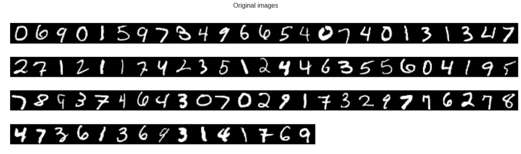

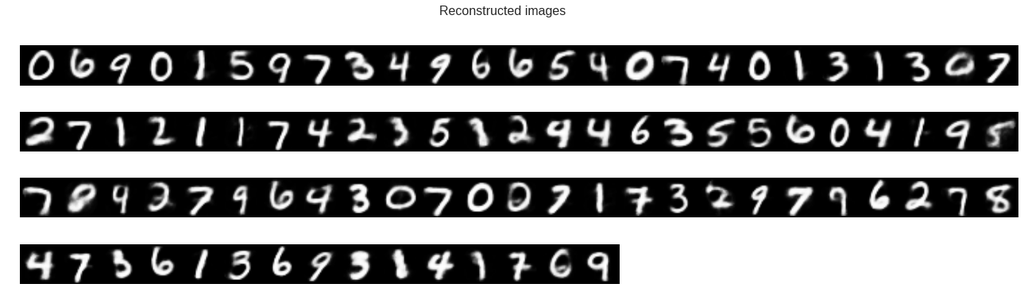

```python
images = mnist.test.images[10:100]
plot_ds(images, 'Original images', (28,28))

decode = autoencoder.decoder.model
decoded = sess.run(decode, feed_dict={autoencoder.inputs: images})
print(decoded.shape)

plot_ds(decoded, 'Reconstructed images', (28,28))
```

## Show Clusters from embedded representation

Using TSNE to visualize the digits clusters from the autoencoded image representations. The cluster are much more visible/not mixed in the 3D space than the ones from the RBM encoding in the preivous notebook. This a a good step forward to the digit clusterization.

However it might not be enought as the clusters are really close to each other. For example the Nearest Neighboor algorithm might not be able to find a frontier between some clusters. One could try to use other clusetring methods, but I'm wondering if the is any way to constrain the autoencoder so that the points of the same digit are closer to each other in the TSNE space.

```python
from sklearn.decomposition import PCA
from sklearn.manifold import TSNE
n=1000
X = mnist.train.images[:n]
Y = np.argmax(mnist.train.labels[:n],1)
encode = autoencoder.encoder.model
encoded = sess.run(encode, feed_dict={autoencoder.inputs: X})

encoded = TSNE(n_components=3).fit_transform(encoded)
scatter_3d(encoded, Y, "autoencoder embedded")
```

[interactive chart not shown]